# Assignment 1

Mildred Unti & Caroline Broderick

2/14/2021

## Data preprocessing

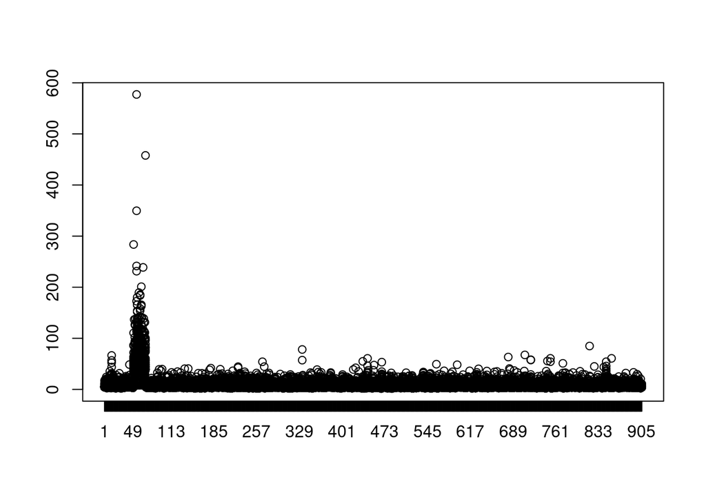

```r
load("/home/x1/Documents/Weill_Cornell/Functional_Interpretation/metabolomics/homework_1/data/Simulated_metabolomics_data.RData")
boxplot(dat, use.cols = FALSE)
```

Data needs to be logged before graphing

```r
library(tidyverse)
```

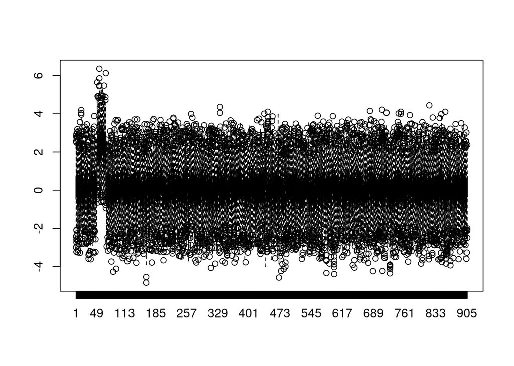

```r
library(ggplot2)
library(rlang)
dat_log <- log(dat)
boxplot(dat_log, use.cols = FALSE)
```

Logged data is easier to visualize. Data needs to be normalized; there are clearly outliers from increased input.

```r
dat_norm <- matrix(nrow = nrow(dat) , ncol = ncol(dat)) #makes a matrix that matches dat where normalized metabolite levels will be placed.
colnames(dat_norm) <- colnames(dat)
rownames(dat_norm) <- rownames(dat)
dat_matrix <- as.matrix(dat) #makes a matrix that resembles dat
for (a in 1:nrow(dat_matrix))
  {
        dat_norm[a, ] <- as.numeric(dat_matrix[a, ] / median(as.numeric(dat_matrix[a, ])))
     } #divides each row by the median of the entire row (sample) and assigns it into the matrix of normalized values
dat_norm_d <- as.data.frame(dat_norm)
log_dat_norm_d <- log(dat_norm_d)
```

Normalized metabolite levels

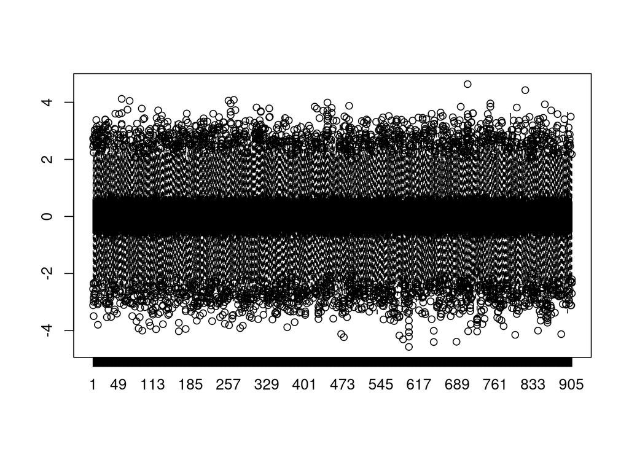

```r
boxplot(log(dat_norm), use.cols = FALSE)
```

There are no longer outliers.

##Phenotype Association To analyze metabolite differences between males and females, we will perform a t-test on each metabolite using gender, then plot the distribution of p-values

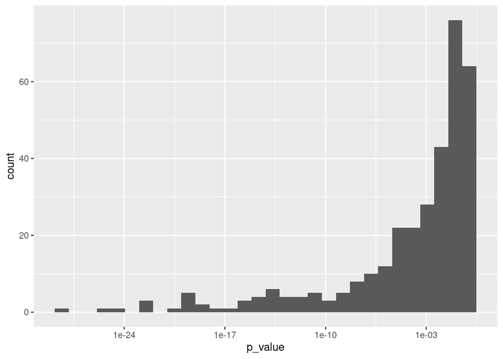

```r
dat1 <- dat_norm_d #using non-logged normalized data
metabolite_p_values <- data.frame(metabolite = character(), p_value = double())#initializes a data frame that contains the name of the metabolite and significance (p-value) of the difference of that metabolite between males and females.

for (i in 1:ncol(dat1)){
  m_name = colnames(dat1)[i] #m_name is a temporary storage vector for the metabolite name
  t_test = t.test(dat1[,m_name]~gender) #calculates differences of  levels of the metabolite at i
  results_temp <- data.frame(metabolite = m_name, p_value = t_test$p.value)#temporary storage of the metabolite name and p_value
  metabolite_p_values <- rbind(metabolite_p_values, results_temp)#adds each metabolite and p value to metabolite_pvalues
}
ggplot(metabolite_p_values, aes(p_value))+geom_histogram()+scale_x_log10()
```

```r
a = .05
a_bonferroni = a/ncol(dat1)
```

The number of metabolites with significant differences before correction are shown below:

```r
sum(metabolite_p_values$p_value < a)
```

```
## [1] 203
```

The number of metabolites with significant differences after correction are shown below:

```r
sum(metabolite_p_values$p_value < a_bonferroni)
```

```
## [1] 115
```

The 10 metabolites with the most significant difference between men and women are shown below.

```r
library(dplyr) #loading this library for merge function
metabolite_p_values$name <- metabolite_p_values$metabolite
metabolite_p_values_annotation <- merge(metabolite_p_values, annotations)
ordered_metabolite_p_values<-metabolite_p_values_annotation[order(metabolite_p_values_annotation$p_value),]
head(ordered_metabolite_p_values, 10)
```

```
##       name metabolite      p_value Super_pathway
## 91  M32418     M32418 4.558675e-29         Lipid
## 159 M33447     M33447 1.447608e-26         Lipid
## 47  M18369     M18369 2.054413e-25       Peptide
## 253 M37190     M37190 3.233489e-23         Lipid
## 182 M33968     M33968 3.598766e-23         Lipid
## 309 M43488     M43488 4.532829e-23       Peptide
## 114 M32672     M32672 2.180985e-21    Amino Acid
## 199 M34456     M34456 1.493333e-20       Peptide
## 71  M27718     M27718 1.651921e-20    Amino Acid
## 34   M1604      M1604 4.038535e-20    Nucleotide
##                                              Sub_pathway
## 91                                 Long Chain Fatty Acid
## 159                                Long Chain Fatty Acid
## 47                             Gamma-glutamyl Amino Acid
```

[output cut: 18 more lines]

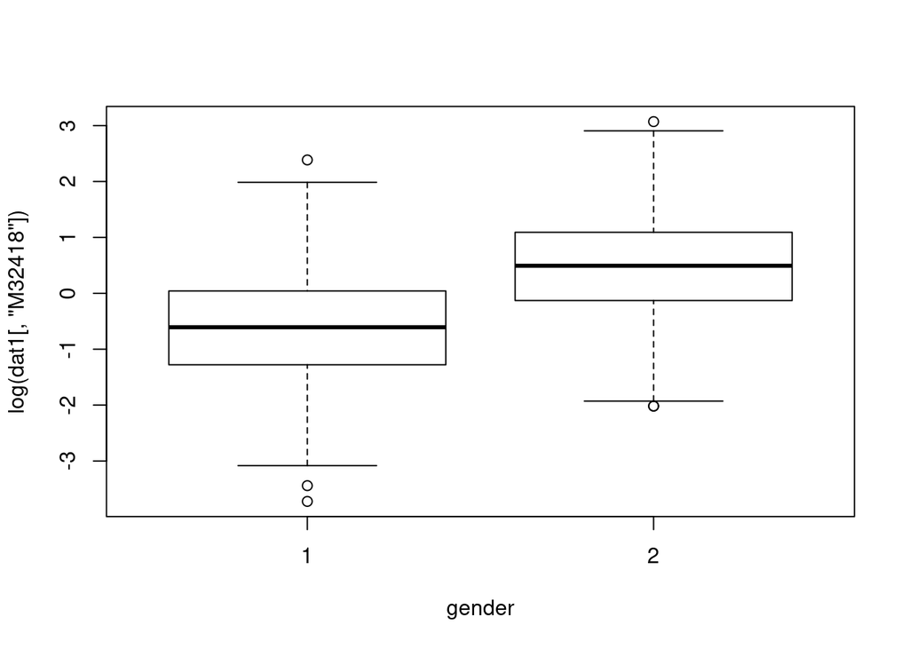

```r
boxplot(log(dat1[,"M32418"])~gender)
```

##Gaussian Graphical Model

```r
library(ppcor)
pcor_results <- pcor(dat1) #pearson
```

Multiple testing Bonferroni correction. All correlations that are not significant after Bonferroni testing are set to 0. All correlations that are between the same metabolite are also set to 0.

```r
num_metabolites <-ncol(dat1)
num_correlations <- ((num_metabolites**2) - num_metabolites)/2
a = .05
a_bf = a/num_correlations
pcor_results_significant <- pcor_results$estimate
for(i in 1:nrow(pcor_results_significant)){
  for( j in 1:ncol(pcor_results_significant)){
    if(pcor_results$p.value[i,j] > a_bf){
      pcor_results_significant[i,j] = 0 #sets all non-significant correlations to 0
    }
    if(i == j)
    {
       pcor_results_significant[i,j] = 0 #sets all correlations between the same metabolite to 0
    }
  }


}
```

igraph can be used to visualize all significant metabolite correlations

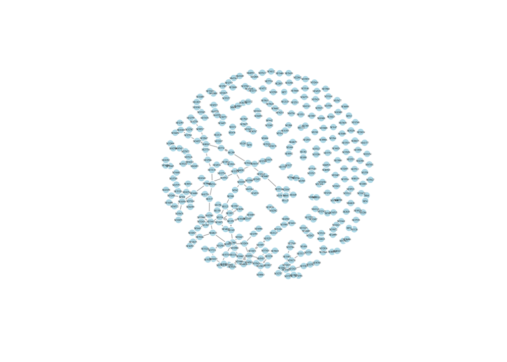

```r
library(igraph)
metabolite_interactions<-graph_from_adjacency_matrix(pcor_results_significant*6, mode = "max" )
graph_metabolite_interactions <- plot(metabolite_interactions, vertex.size = 7, vertex.label.cex = 0.2, vertex.label.family="Times",  vertex.label.color = "black", vertex.frame.color = "white", vertex.color = "lightblue" )
```